# Trabajo práctico 1 - Laboratorio de datos - 2do cuatrimestre 2021

### Integrantes: Ariel Oliveira, Manuel Nores, Tomás Curti.

## Carga de datos

Empezamos por cargar los archivos csv a Rstudio para poder visualizar los data frames. Por un lado tenemos el dataframe de los vuelos durante el 2021 y por otro lado tenemos el dataframe de aeropuertos en territorio Argentino.

En el data frame de los vuelos registrados durante el 2021 notamos que los nombres de algunas columnas no nos resultaban ideales de manera tal que los cambiamos. Por un lado nos reemplazamos los espacios por guiones bajos y renombramos dos variables.

También cambiamos el nombre de algunas variables del data frame de aeropuertos, reemplzando acrónimos por su significado para que resultara mas conveniente la exploración de datos.

```r
library(readr)
library(tidyverse)
library(lubridate)
df_aeropuertos <- read_csv("aeropuertos.csv")
df_vuelos <- read_csv("vuelos.csv")
df_vuelos = df_vuelos %>%
  setNames(tolower(gsub(" ","_",names(.)))) %>%
  rename("clase_de_vuelo" = "clase_de_vuelo_(todos_los_vuelos)") %>%
  rename("origen_destino" = "origen_/_destino") %>%
  print(n=10)
```

```
## # A tibble: 219,803 x 11
##    fecha      hora_utc clase_de_vuelo clasificación_v~ tipo_de_movimie~ aeropuerto
##    <chr>      <time>   <chr>          <chr>            <chr>            <chr>
##  1 01/01/2021 00:02    Vuelo Privado~ Dom              Despegue         PAR
##  2 01/01/2021 00:24    Regular        Dom              Aterrizaje       EZE
##  3 01/01/2021 00:26    Regular        Dom              Aterrizaje       EZE
##  4 01/01/2021 00:29    Regular        Dom              Aterrizaje       EZE
##  5 01/01/2021 00:37    Regular        Dom              Aterrizaje       EZE
##  6 01/01/2021 00:59    Regular        Inter            Aterrizaje       EZE
##  7 01/01/2021 01:00    Vuelo Privado~ Dom              Aterrizaje       ROS
##  8 01/01/2021 01:12    Regular        Inter            Despegue         EZE
##  9 01/01/2021 01:52    Regular        Inter            Despegue         EZE
## 10 01/01/2021 02:08    Regular        Inter            Despegue         EZE
## # ... with 219,793 more rows, and 5 more variables: origen_destino <chr>,
## #   aerolinea_nombre <chr>, aeronave <chr>, pasajeros <dbl>, calidad_dato <chr>
```

```r
df_aeropuertos = df_aeropuertos %>%
  setNames(tolower(gsub(" ","_",names(.)))) %>%
  select(-iko, -ita, -fuc, -ose, -nom_ciudad) %>%
  rename("ciudad" = "nam") %>%
  rename("provincia" = "cpr") %>%
  rename("aeropuerto" = "fna") %>%
  rename("latitud" = "x") %>%
  rename("longitud" = "y")
```

## Limpieza del data frame:

En este punto pudimos explorar el data frame y decidimos hacer unos filtrados para quedarnos con partes específicas.

En primer lugar filtramos por clasificación de vuelo Doméstico, de manera que nos quedamos con los vuelos de cabotaje. Nos deshicimos de todos los registros donde el nombre de la aerolínea fuera un cero, ya que estos coincidian con vuelos privados. En general de pocos o ningún pasajero. Otro filtro que aplicamos fue que la calidad de dato sea “DEFINITIVO”, ya que había varios datos con calidad “PROVISORIA” y nos pareció mejor trabajar con aquellos datos que ya completaron el camino de validación por completo. El último filtro que aplicamos fue el de clase de vuelo regular, para quedarnos con los vuelos realizados por aerolineas y accesibles a cualquier consumidor final. Más adelante veremos mas en detalle por que esto nos resultó importante.

Por último, reescribimos la variable origen/destino en dos variables separadas de manera que tenemos una columna para el origen y otra para el destino para todos los registros de vuelos.

```r
df_vuelos = df_vuelos %>%
  filter(clasificación_vuelo == "Dom") %>%
  filter(aerolinea_nombre != "0") %>%
  filter(calidad_dato == "DEFINITIVO") %>%
  filter(clase_de_vuelo == "Regular") %>%
  mutate(origen = case_when(tipo_de_movimiento == "Despegue" ~ aeropuerto,
                            tipo_de_movimiento == "Aterrizaje" ~ origen_destino)) %>%
  mutate(destino = case_when(tipo_de_movimiento == "Aterrizaje" ~ aeropuerto,
                            tipo_de_movimiento == "Despegue" ~ origen_destino)) %>%
  mutate(time = dmy_hms(paste(fecha, hora_utc, sep=" "))) %>%
  select(-fecha, -hora_utc, -clasificación_vuelo, -origen_destino, -aeropuerto, -clase_de_vuelo, -calidad_dato)


df_aeropuertos
```

```
## # A tibble: 56 x 9
##       id provincia      pais      ciudad aeropuerto ana   thr   latitud longitud
##    <dbl> <chr>          <chr>     <chr>  <chr>      <chr> <chr>   <dbl>    <dbl>
##  1    15 Santa Cruz     Argentina El Ca~ Aeropuert~ ECA   NAC     -72.1    -50.3
##  2    68 Tierra Del Fue Argentina Ushua~ Aeropuert~ USU   INTL    -68.3    -54.8
##  3    46 Santa cruz     Argentina Rio G~ Aeropuert~ GAL   INTL    -69.3    -51.6
##  4    47 Tierra Del Fue Argentina Río G~ Aeropuert~ GRA   INTL    -67.8    -53.8
##  5    17 Chubut         Argentina Esquel Aeropuert~ ESQ   NAC     -71.1    -42.9
##  6     4 Río Negro      Argentina San C~ Aeropuert~ BAR   INTL    -71.2    -41.2
##  7     7 Neuquén        Argentina San M~ Aeropuert~ CHP   NAC     -71.1    -40.1
##  8    33 Neuquén        Argentina Neuqu~ Aeropuert~ NEU   INTL    -68.2    -38.9
##  9    59 Mendoza        Argentina San R~ Aeropuert~ SRA   NAC     -68.4    -34.6
## 10    31 Mendoza        Argentina Mendo~ Aeropuert~ DOZ   INTL    -68.8    -32.8
## # ... with 46 more rows
```

```r
df_vuelos
```

```
## # A tibble: 45,146 x 7
##    tipo_de_movimiento aerolinea_nombre     aeronave     pasajeros origen destino
##    <chr>              <chr>                <chr>            <dbl> <chr>  <chr>
##  1 Aterrizaje         AEROLINEAS ARGENTIN~ BO-B737-8MB         70 GRA    EZE
##  2 Aterrizaje         AEROLINEAS ARGENTIN~ BO-737-800          70 ECA    EZE
##  3 Aterrizaje         AEROLINEAS ARGENTIN~ BO-B-737-76N        12 SAL    EZE
##  4 Aterrizaje         AEROLINEAS ARGENTIN~ EMB-ERJ1901~        26 TUC    EZE
##  5 Despegue           AEROLINEAS ARGENTIN~ BO-B737-800         35 EZE    ECA
##  6 Despegue           AEROLINEAS ARGENTIN~ EMB-ERJ1901~        46 EZE    JUJ
##  7 Despegue           AEROLINEAS ARGENTIN~ BO-737-800          81 EZE    BAR
##  8 Despegue           AEROLINEAS ARGENTIN~ BO-B737-8MB         74 EZE    USU
##  9 Despegue           AEROLINEAS ARGENTIN~ BO-B737-800         67 EZE    NEU
## 10 Despegue           AEROLINEAS ARGENTIN~ BO-737-8SH          71 EZE    USU
## # ... with 45,136 more rows, and 1 more variable: time <dttm>
```

## Cálculo de tiempo en vuelo

En esta sección utilizamos los tiempos de despegue y aterrizaje para poder calcular el tiempo de vuelo en cada registro.

También aplicamos un filtro para quedarnos con aquellos registros que hayan tenido menos de 7 horas de vuelo, ya que en ese tiempo puede hacerse el viaje mas largo en la Argentina.

```r
despegues = df_vuelos %>% filter(tipo_de_movimiento == "Despegue") %>% select(-tipo_de_movimiento)
aterrizajes = df_vuelos %>% filter(tipo_de_movimiento == "Aterrizaje") %>% select(-tipo_de_movimiento)

df_vuelos2 = left_join(despegues, aterrizajes, by= c("origen" = "origen",
                                                    "destino" = "destino",
                                                    "aerolinea_nombre" = "aerolinea_nombre",
                                                    "aeronave" = "aeronave"), suffix = c("_salida", "_llegada")) %>%
  mutate(tiempo_de_vuelo = time_llegada - time_salida)  %>%
  filter(tiempo_de_vuelo > 0) %>%
  filter(aerolinea_nombre != "0") %>%
  filter(tiempo_de_vuelo < 7*3600) %>%
  print(5)
```

```
## # A
## #   tibble:
## #   21,904
## #   x
## #   9
```

## Fusión de los data sets:

En este chunk lo que logramos es fucionar ambos data sets en uno único, usando como clave de unión a la variable “ana” que hace referencia a las siglas de las ciudades.

```r
df_vuelosConAeropuertos = df_vuelos2 %>%
  inner_join(df_aeropuertos, by = c("origen" = "ana")) %>%
  inner_join(df_aeropuertos, by = c("destino" = "ana"), suffix = c("_origen", "_destino")) %>%
  print(5)
```

```
## # A
## #   tibble:
## #   21,904
## #   x
## #   25
```

## Cálculo de distancias recorridas por los aviones.

En este apartado utilizamos el paquete geosphere para poder calcular las distancias recorridas por los aviones en función de las coordenadas de despegue y aterrizaje. Para lograr esto utilizamos la función distHaversine provista por el paquete mencionado.

```r
library(geosphere)

df_vuelosConAeropuertos = df_vuelosConAeropuertos %>%
  rowwise %>%
  mutate(distancia = distHaversine(c(latitud_origen, longitud_origen), c(latitud_destino, longitud_destino)))
```

## Análisis del dataset procesado:

Hasta acá hicimos una limpieza y procesado de los datos para llegar a una base de datos con la cual vamos a trabajar para poner a prueba nuestras hipotesis. Pero, ¿Cuáles son nuestras hipotesis?

### Hipótesis:

Por un lado nos interesa averiguar la cantidad de personas que salieron y entraron a cada provincia. Lo que nos motivo a hacer esto es ver si hay alguna tendencia de “migración” en alguna provincia y en el caso de que así sea, ver hacia donde es que la gente está yendo.

Por otro lado, nos preguntamos el porcentaje del mercado que se lleva cada aerolínea. La forma en la que cuantificaremos la porción del mercado consistirá en la cantidad de tiempo de vuelo que tiene cada aerolinea por sobre el total, pesado por la cantidad de pasajeros totales transportados.

### Empecemos por ver la cantidad de gente que salió y entró a cada provincia.

### Notamos que hay errores en la cantidad de pasajeros entre el despegue y el aterrizaje, es decir, que un mismo registro aparenta haber salido con una cantidad distinta de pasajeros a la que llegó. La forma que lidiamos con esto fue quedarnos con los que tienen una diferencia menor a 10 pasajeros. La Rioja no tiene salidas registradas por lo que le pusimos 0 en pasajeros que salieron de la provincia para que no quede NA como dato.

Finalmente definimos la “divergencia” de cada provincia a partir de la diferencia entre la gente que salió y la gente que entró a la provincia.

```r
salieron_de_provincia = df_vuelosConAeropuertos %>%
  na.omit() %>%
  filter(abs(pasajeros_salida - pasajeros_llegada)<10) %>%
  group_by(provincia_origen) %>%
  summarise(salieron = sum(pasajeros_salida))

entraron_a_provincia = df_vuelosConAeropuertos %>%
  na.omit() %>%
  filter(abs(pasajeros_salida - pasajeros_llegada)<10) %>%
  group_by(provincia_destino) %>%
  summarise(entraron = sum(pasajeros_llegada))


div = left_join(entraron_a_provincia, salieron_de_provincia, by=c("provincia_destino" = "provincia_origen")) %>%
  rename("provincia" = "provincia_destino") %>%
  mutate(migraron = entraron - salieron) %>%
  arrange(provincia)

div[div$provincia == "La Rioja", "migraron"] = 55
div[div$provincia == "La Rioja", "salieron"] = 0


div[div$provincia == "Sgo. del Ester", "provincia"] = "Santiago del Estero"
div[div$provincia == "Tucuman", "provincia"] = "Tucumán"
div[div$provincia == "Tierra Del Fue", "provincia"] = "Tierra del Fuego, Antártida e Islas del Atlántico Sur"
div[div$provincia == "Capital Federa", "provincia"] = "Ciudad Autónoma de Buenos Aires"


div
```

```
## # A tibble: 25 x 4
##    provincia                       entraron salieron migraron
##    <chr>                              <dbl>    <dbl>    <dbl>
##  1 Buenos Aires                      218570   270543   -51973
##  2 Ciudad Autónoma de Buenos Aires   270245   264845     5400
##  3 Catamarca                            435      409       26
##  4 Chaco                               7617     7212      405
##  5 Chubut                             32113    30127     1986
##  6 Cordoba                              652      734      -82
##  7 Córdoba                            64199    63001     1198
##  8 Corrientes                          4402     5140     -738
##  9 Entre Ríos                           606      580       26
## 10 Jujuy                              14609    13503     1106
## # ... with 15 more rows
```

De este análisis pudimos ver que la provincia con menor divergencia (notar que la divergencia negativa está vinculada a la salida de personas) es la provincia de Buenos Aires. Tuvo una migración de 52 mil personas aproximadamente durante el 2021. Veamos el siguiente mapa de colores para poder visualizar la divergencia de cada provincia:

```r
library(sf)
```

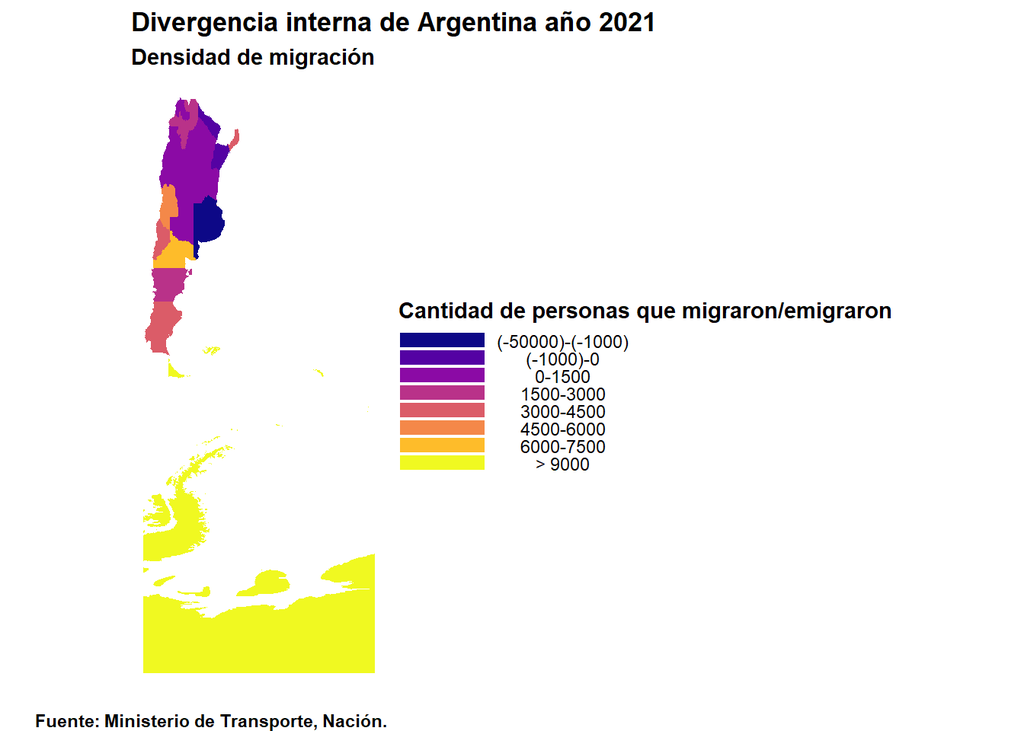

```r
arg_provincias = read_sf("./shapefile","ign_provincia")
arg_provincias = arg_provincias %>% left_join(div, by=c("NAM" = "provincia"))
arg_provincias[arg_provincias$NAM == "Formosa", "entraron"] = 0
arg_provincias[arg_provincias$NAM == "Formosa", "salieron"] = 0
arg_provincias[arg_provincias$NAM == "Formosa", "migraron"] = 0


arg_provincias$claseMigracion <- cut(arg_provincias$migraron ,breaks=c((-60000),(-1000),0,1500,3000, 4500, 6000, 7500, 9000, Inf),
                        labels=c('(-50000)-(-1000)','(-1000)-0','0-1500','1500-3000','3000-4500','4500-6000','6000-7500','7500-9000','> 9000'))

ggplot(arg_provincias)+
  geom_sf(aes(fill=claseMigracion),color='transparent')+
  scale_fill_viridis_d(name='Cantidad de personas que migraron/emigraron',
                       guide=guide_legend(
                         direction='vertical',
                         title.position='top',
                         title.hjust = .5,
                         label.hjust = .5,
                         label.position = 'right',
                         keywidth = 3,
                         keyheight = .5
                       ),
                       option = "C")+

  labs(title="Divergencia interna de Argentina año 2021",
       subtitle='Densidad de migración',
       caption=c('Fuente: Ministerio de Transporte, Nación.'))+
  theme_void()+
  theme(title=element_text(face='bold'),
        legend.position = 'right')
```

### Análisis de la divergencia:

Ninguna otra provincia tuvo una salida considerable de gente. Esto nos generó nuevas preguntas. Por ejemplo, hacia donde va la gente que sale de Buenos Aires?? Para poder analizar eso hacemos una busqueda específica sobre los destinos a los cuales fue la gente que salió desde Buenos Aires. Para lograr eso generamos el siguiente código:

```r
provincias_BsAs = df_vuelosConAeropuertos %>%
  filter(provincia_destino == "Buenos Aires") %>%
  na.omit() %>%
  filter(abs(pasajeros_salida - pasajeros_llegada)<10) %>%
  group_by(provincia_origen) %>%
  summarize(entraronBsAs = sum(pasajeros_llegada))


BsAs_provincias = df_vuelosConAeropuertos %>%
  filter(provincia_origen == "Buenos Aires") %>%
  na.omit() %>%
  filter(abs(pasajeros_salida - pasajeros_llegada)<10) %>%
  group_by(provincia_destino) %>%
  summarise(salieronBsAs = sum(pasajeros_salida))

migracionBsAs = left_join(BsAs_provincias, provincias_BsAs, by=c("provincia_destino" = "provincia_origen")) %>%
  rename("provincia" = "provincia_destino")

migracionBsAs[migracionBsAs$provincia == "Sgo. del Ester", "provincia"] = "Santiago del Estero"
migracionBsAs[migracionBsAs$provincia == "Tucuman", "provincia"] = "Tucumán"
migracionBsAs[migracionBsAs$provincia == "Tierra Del Fue", "provincia"] = "Tierra del Fuego, Antártida e Islas del Atlántico Sur"
migracionBsAs[migracionBsAs$provincia == "Capital Federa", "provincia"] = "Ciudad Autónoma de Buenos Aires"

migracionBsAs = migracionBsAs %>%
  mutate(migraronBsAs = salieronBsAs - entraronBsAs)

migracionBsAs[migracionBsAs$provincia == "Buenos Aires", "migraronBsAs"] = 0
```

### Que hace el código:

```r
arg_provincias = arg_provincias %>% left_join(migracionBsAs, by=c("NAM" = "provincia"))
arg_provincias[arg_provincias$NAM == "La Rioja", "migraronBsAs"] = 0
arg_provincias[arg_provincias$NAM == "Formosa", "migraronBsAs"] = 0
arg_provincias %>% select("NAM", migraronBsAs)
```

```
## Simple feature collection with 24 features and 2 fields
## Geometry type: MULTIPOLYGON
## Dimension:     XYZ
## Bounding box:  xmin: -74 ymin: -90 xmax: -25 ymax: -21.78086
## z_range:       zmin: 0 zmax: 0
## Geodetic CRS:  WGS 84 + WGS_1984_Geoid
## # A tibble: 24 x 3
##    NAM                             migraronBsAs                         geometry
##    <chr>                                  <dbl>               <MULTIPOLYGON [°]>
##  1 Ciudad Autónoma de Buenos Aires          460 Z (((-58.34189 -34.6311 0, -58.~
##  2 Neuquén                                 3587 Z (((-70.39345 -36.15526 0, -70~
##  3 La Pampa                                 -25 Z (((-64.76547 -40.78351 0, -64~
##  4 Mendoza                                 6233 Z (((-69.1257 -32.00283 0, -69.~
##  5 San Luis                                 217 Z (((-67.05547 -31.85605 0, -67~
##  6 Córdoba                                 5034 Z (((-63.87035 -29.62387 0, -63~
##  7 Santa Fe                                 355 Z (((-60.27271 -33.26386 0, -60~
##  8 Entre Ríos                                33 Z (((-58.58138 -30.1601 0, -58.~
##  9 San Juan                                 366 Z (((-69.62981 -28.39369 0, -69~
## 10 La Rioja                                   0 Z (((-68.52083 -27.81988 0, -68~
## # ... with 14 more rows
```

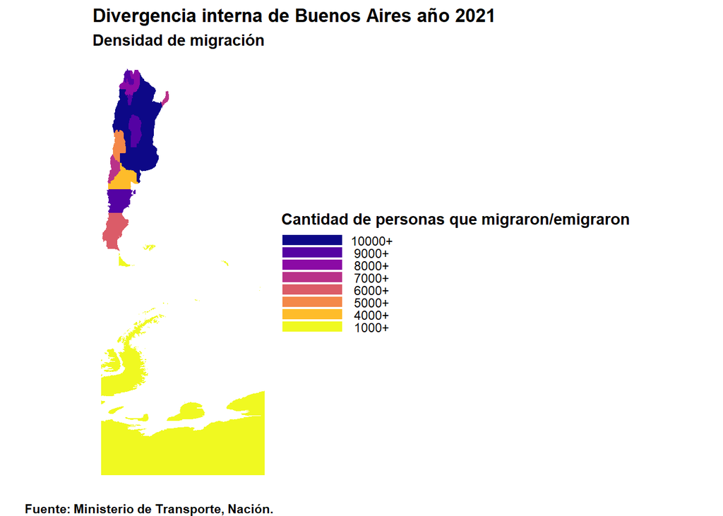

```r
arg_provincias$claseMigracion <- cut(arg_provincias$migraron ,breaks=c(Inf, (10000),(9000),8000,7000,6000, 5000, 4000, 3000, 2000, 1000, -Inf),
                        labels=c('10000+','9000+','8000+','7000+','6000+','5000+','4000+','3000+','2000+','1000+','0'))

ggplot(arg_provincias)+
  geom_sf(aes(fill=claseMigracion),color='transparent',inherit.aes = TRUE)+
  scale_fill_viridis_d(name='Cantidad de personas que migraron/emigraron',
                       guide=guide_legend(
                         direction='vertical',
                         title.position='top',
                         title.hjust = .5,
                         label.hjust = .5,
                         label.position = 'right',
                         keywidth = 3,
                         keyheight = .5
                       ),
                       option = "C")+

  labs(title="Divergencia interna de Buenos Aires año 2021",
       subtitle='Densidad de migración',
       caption=c('Fuente: Ministerio de Transporte, Nación.'))+
  theme_void()+
  theme(title=element_text(face='bold'),
        legend.position = 'right')
```

## Análisis de porción de mercado según aerolínea:

En esta sección analizaremos la parte de mercado de vuelos que se llevó cada aerolínea. Para ello vamos a implementar un código que calcula la cantidad total de pasajeros que viajó en cada aerolínea y qué tiempo de vuelo tuvieron. Nuestra hipótesis es que las personas deciden viajar más con “Aerolineas Argentinas”, por un lado porque es la de más renombre, y por otro, porque al ser una empresa estatal hay mayor predispocisión política de brindar un servicio que llegue a todo el país.

```r
pasajeros_aerolineas =  df_vuelos2 %>% group_by(aerolinea_nombre) %>%
filter(pasajeros_salida > 20) %>%
  summarise(pasajeros = sum(pasajeros_salida), tiempoVuelo = sum(tiempo_de_vuelo))
show(pasajeros_aerolineas)
```

```
## # A tibble: 3 x 3
##   aerolinea_nombre            pasajeros tiempoVuelo
##   <chr>                           <dbl> <drtn>
## 1 AEROLINEAS ARGENTINAS SA       850432 103647840 secs
## 2 FB LÍNEAS AÉREAS - FLYBONDI    132332   9610260 secs
## 3 JETSMART AIRLINES S.A.         149002  16857720 secs
```

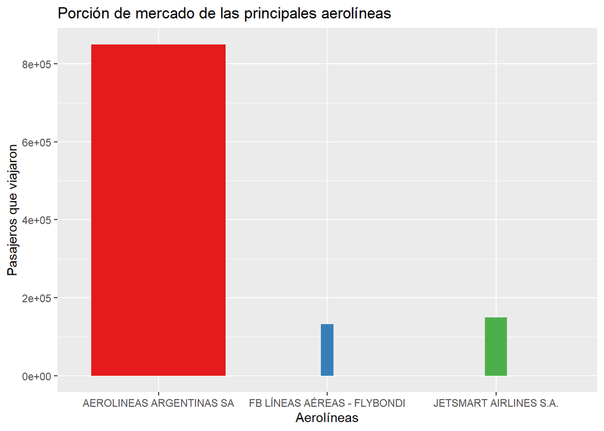

```r
library(RColorBrewer)
coul <- brewer.pal(6, "Set2")


ggplot(pasajeros_aerolineas, aes(x=aerolinea_nombre,y=pasajeros, fill=aerolinea_nombre )) +
  geom_bar(stat='identity',
           width=as.numeric(pasajeros_aerolineas$tiempoVuelo)/as.numeric(sum(pasajeros_aerolineas$tiempoVuelo)) ) +
  scale_fill_brewer(palette = "Set1") +
  ggtitle("Porción de mercado de las principales aerolíneas") +
  xlab("Aerolíneas") +
  ylab("Pasajeros que viajaron") +
  theme(legend.position="none")
```

Tal como pensabamos Aerolineas Argentinas es la aerolinea que mas pasajeros transporto, esto no nos asombra ya que al observar su ancho es tambien de la que mas vuelos figuran en el dataframe, lo que puede deberse a su política. Luego, le siguen Jetsmart y Flybondi, dos conocidas aerolineas low-cost.